# Laser Inertial Confinement Fusion (ICF)

## Jacob Shin

### 11/11/2022

[figure not shown]

- Two lighter nuclei combine and form a heavier, more stable nuclei
- Releases a lot of energy

$$ E = \Delta m c^2 $$

# Ways of doing Fusion

- The two nuceli must overcome colomb repulsion before the strong force kicks in
- This means you have some force that confines the nuclei

| Gravity | Magnets | Lasers |
| --- | --- | --- |

- In order for a fusion reactor to be useful, it has to produce more energy than what we put in:

$$Q = \frac{\text{Energy Released by Fusion}}{\text{Input Energy}}$$$$Q_{fuel} = \frac{\text{Energy Released by Fusion}}{\text{Energy Absorbed by Fuel}}$$

## Lawson Criteria/Triple Product

$$ nT\tau_E \ge \frac{3T^2}{(f_c + Q_{fuel}^{-1} ) ⟨\sigma v⟩ \epsilon_f/4 - C_B \sqrt{T} } $$

- While running a fusion reactor, some of the energy is lost
- $n$ is the density of the fuel
- $T$ is the temperature of the fuel
- $\tau_E$ is the confinement time, which tells you how long to keep the fuel confined together
- $v$ is the fuel particles' velocity
- $f_c$, $\sigma$, $C_B$, $\eta$, $\epsilon_F$ are all constants that depends on the fuel

```python
from IPython.display import HTML; HTML('<blockquote class="twitter-tweet"><p lang="en" dir="ltr">&quot;Progress toward fusion energy breakeven and gain as measured against the Lawson criterion&quot; by <a href="https://twitter.com/ScottCHsu?ref_src=twsrc%5Etfw">@ScottCHsu</a> and myself is published (open access)! GIF of achieved Lawson parameter vs temperature below shows the progress. <a href="https://t.co/VKFM1XubXR">https://t.co/VKFM1XubXR</a> <a href="https://twitter.com/hashtag/fusionenergy?src=hash&amp;ref_src=twsrc%5Etfw">#fusionenergy</a> <a href="https://twitter.com/ARPAE?ref_src=twsrc%5Etfw">@ARPAE</a> <a href="https://twitter.com/AIP_Publishing?ref_src=twsrc%5Etfw">@AIP_Publishing</a> <a href="https://t.co/P1oNjLB8ZN">pic.twitter.com/P1oNjLB8ZN</a></p>&mdash; Sam Wurzel (@swurzel) <a href="https://twitter.com/swurzel/status/1534556521744457731?ref_src=twsrc%5Etfw">June 8, 2022</a></blockquote> <script async src="https://platform.twitter.com/widgets.js" charset="utf-8"></script> ')
```

> "Progress toward fusion energy breakeven and gain as measured against the Lawson criterion" by [@ScottCHsu](https://twitter.com/ScottCHsu?ref_src=twsrc%5Etfw) and myself is published (open access)! GIF of achieved Lawson parameter vs temperature below shows the progress. https://t.co/VKFM1XubXR [#fusionenergy](https://twitter.com/hashtag/fusionenergy?src=hash&ref_src=twsrc%5Etfw) [@ARPAE](https://twitter.com/ARPAE?ref_src=twsrc%5Etfw) [@AIP_Publishing](https://twitter.com/AIP_Publishing?ref_src=twsrc%5Etfw) [pic.twitter.com/P1oNjLB8ZN](https://t.co/P1oNjLB8ZN)

> — Sam Wurzel (@swurzel) [June 8, 2022](https://twitter.com/swurzel/status/1534556521744457731?ref_src=twsrc%5Etfw)

# Direct Drive vs. Indirect Drive

- Direct Drive is 8% efficient, but harder to get spherical symmetry
- Indirect Drive is only 4% efficient, allows for more symmetric implosion and less instabilities

[figure not shown]

$$ P dV = T dS - dU$$

- Minimize work
- Images from https://suli.pppl.gov/2020/course/Ma_IFE_SULI2020_20200626.pdf

[figure not shown]

Source: https://en.wikipedia.org/wiki/National_Ignition_Facility#/media/File:NIF_building_layout.png

# National Ignition Facility (NIF): World's Largest Laser

- UV Laser: 1.8 megajoules
- UV Laser Peak Power: 500 TW
- 100 times density of lead at ignition
- 100 million kelvins (6 times Temp at core of the sun)
- More Fun facts: https://lasers.llnl.gov/content/assets/docs/news/pk_fun_facts2.pdf

[output not shown]

[figure not shown]

Source: https://lasers.llnl.gov/content/assets/images/about/

# Pockell Cell, Main Amplifier, and Polarizer

[figure not shown]

- KDP (Potassium Diphosphate) is birefringent -- has two different indices of refraction
- KDP experiences Pockell's Effect
  - If an electric field is applied to the crystal, the index of refraction changes $$|\Delta n| = \frac{r}{2} n_0^3 E $$

    where $r$ is the an electro-optical coefficient for KDP and $n_0$ is the initial index of refraction at $E=0$, and $\Delta n$ is the change in index of refraction

[figure not shown]

- Plasmas are ionized gases - highly conductive due to the free electrons present
- Density of electrons, $n_e$, determines reflectivity $$ \omega_p = 2\pi f_p = \sqrt{\frac{n_e e^2}{\epsilon_0 m_e}}$$
- When the frequency of incoming light, $f_i$, is greater than the plasma frequency, then there is transmission of the light through the plasma $$ f_i > f_p $$

This explains why AM radio waves bounce off of the ionosphere ($n_e \approx 10^{11}$), why metals are reflective and shiny ($n_e \approx 10^{28}$), and why the surface of the sun isn't shiny ($n_e \approx 10^{20}$), and why helium plasma is used for the Pockell cell ($n_e \approx 10^{18}$)

- $ n_e = 10^{12} \ cm^{-3} = 10^{18} m^{-3}$, $e=1.6 \times 10^{-19}\ C$, $m_e = 9.10 \times 10^{-31} \ kg$, $\epsilon_0 = 8.85 \times 10^{-12}$
- $\lambda_i=1053\ nm$

$$ f_p = \frac{1}{2\pi} \sqrt{\frac{10^{18} \cdot (1.6 \times 10^{-19})^2}{8.85 \times 10^{-12} \cdot 9.10 \times 10^{-31}}} = 8.9 \ GHz$$$$ f_i = \frac{c}{\lambda_i} = 285 \ THz$$

Thus $f_i >> f_p$ means the laser will be transmitted through the helium plasma

[figure not shown]

# Second Harmonic Generation

$$ P_2 = \epsilon_0 \chi_2 E^2 $$$$ E = E_0 \cos \omega t$$$$ \implies P_2 = \epsilon_0 \chi_2 E_0^2 \cos^2 \omega t = \epsilon_0 \chi_2 \epsilon_0^2 \left(\frac{1}{2}(1+ \cos 2 \omega t)\right)$$

Using double angle formulas, we get the following:

$$ P_2 = \frac{1}{2} \epsilon_0 \chi_2 E_0^2 + \frac{1}{2} \epsilon_0 \chi_2 E_0^2 \cos 2 \omega t$$

# Spatial Filters

[figure not shown]

# Why is Fusion Hard?

- Instabilities/Turbulence: Rayleigh Taylor, Kelvin-Helmholtz, Richtmyer–Meshkov, Wakes
- Scattering: Laser light entering the hohlrahm gets scattered (absorbed by electrons and gold plasma), which reduces the energy that reaches the fuel
  - Stimulated Raman Scattering (SRS)
  - Stimulated Brillouin Scattering (SBS)

# Raman Scattering

- (Spontaneous) Incoming laser photon scatters inelastically
  - The photon from the laser (called a pump photon) is inelastically scattered with some energy transferred into vibrational energy in the molecule
  - The remaining photon has a lower energy (lower frequency) -- Called the stoke's photon
- (Stimluated) Some of the stoke's photons emitted from spontaneous Raman scattering act as seed photons
  - Pump photon + stokes photons interact with molecules and cause vibrations

# Wakes

- Wakes can be used for particle accelerators!
- Wakefield: 1GeV with only 3.3 cm, SLAC: 64 meters

[figure not shown]

```python
import matplotlib.pyplot as plt
%matplotlib notebook
import happi; S=happi.Open(); Rho = S.Field.Field0("-Rho",cmap="Blues_r",vmax=0.01); Env_E = S.Field.Field0("Env_E_abs",cmap="hot",vmin=1,transparent="under")
```

```
Loaded simulation '.'
Scanning for Scalar diagnostics
Scanning for Field diagnostics
Scanning for Probe diagnostics
Scanning for ParticleBinning diagnostics
Scanning for RadiationSpectrum diagnostics
Scanning for Performance diagnostics
Scanning for Screen diagnostics
Scanning for Tracked particle diagnostics
```

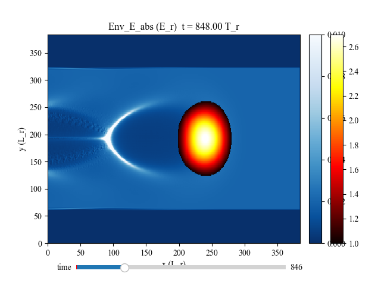

```python
happi.multiSlide(Rho,Env_E)
```

```python
from IPython.display import IFrame
IFrame('./eScholarship UC item 5wb109v8.pdf', width=1200, height=600)
```

[interactive chart not shown]

# Image Credits

- Dr. Otto Octavius
  - https://tenor.com/view/the-power-of-the-sun-in-the-palm-of-my-hand-doctor-octopus-doc-ock-otto-octavius-spider-man-no-way-home-gif-25180157
- Binding Energy
  - https://en.wikipedia.org/wiki/Nuclear_fusion#/media/File:Binding_energy_curve_-_common_isotopes.svg
- Smiling Sun
  - https://solarsystem.nasa.gov/solar-system/sun/overview/
- ITER
  - https://www.iter.org/proj/inafewlines
- NIF
  - https://lasers.llnl.gov/about/seven-wonders
- DT Fusion
  - https://en.wikipedia.org/wiki/Deuterium%E2%80%93tritium_fusion#/media/File:Deuterium-tritium_fusion.svg
- ICF Implosion and Direct/Indirect Drive photos
  - `Badziak, J.. (2012). Laser nuclear fusion: Current status, challenges and prospect. Bulletin of the Polish Academy of Sciences, Technical Sciences. 60. 729. 10.2478/v10175-012-0084-8.`
  - https://journals.pan.pl/dlibra/publication/96903/edition/83651/content
- Fuel Capsule Layers
  - National Academies: https://nap.nationalacademies.org/read/18288/chapter/4
- Spatial Filter Lion Image:
  - https://lasers.llnl.gov/media/photo-gallery
- KDP Crystals
  - https://commons.wikimedia.org/wiki/File:KDP_crystal.jpg
  - https://www.photonics.com/Articles/Cleveland_Crystals_Small_Firm_with_a_Big_Role_in/a30633
- Capacitor Bay
  - https://lasers.llnl.gov/about/how-nif-works/power-conditioning
- Final Optics
  - https://lasers.llnl.gov/about/how-nif-works/final-optics
- Master Oscillator
  - https://lasers.llnl.gov/about/how-nif-works/injection-laser-system
- Pockell Cell and Polarizer
  - https://apps.dtic.mil/sti/pdfs/ADA609999.pdf

# Sources and Further Reading

- NIF User Guide (For scientists):
  - https://nifuserguide.llnl.gov/
- NIF General Public Page:
  - https://lasers.llnl.gov/about/what-is-nif
- Optical Engineering of the NIF
  - https://www.spiedigitallibrary.org/conference-proceedings-of-SPIE/5001?webSyncID=024ddbc2-7cdd-42e4-d28c-c7a6109d29bb&sessionGUID=13628c99-d178-288d-9e26-998d2d18b0c2&_ga=2.95623509.811125676.1664057879-1230779701.1664057879&cm_mc_uid=37792490894716640578790&cm_mc_sid_50300000=68086551664057879099&SSO=1
  - https://www.spiedigitallibrary.org/conference-proceedings-of-SPIE/5341?webSyncID=024ddbc2-7cdd-42e4-d28c-c7a6109d29bb&sessionGUID=13628c99-d178-288d-9e26-998d2d18b0c2&_ga=2.61414885.811125676.1664057879-1230779701.1664057879&cm_mc_uid=37792490894716640578790&cm_mc_sid_50300000=68086551664057879099#KeynoteSession
- 2022 SULI Inertial Confinement Fusion Presentation
  - https://suli.pppl.gov/2022/course/Kraus_icfIntro_SULItalks2022_220615.pdf
- 2020 SULI Inertial Confinement Fusion Presentation
  - https://suli.pppl.gov/2020/course/Ma_IFE_SULI2020_20200626.pdf
- Simulate Wakefield Acceleration:
  - https://smileipic.github.io/tutorials/advanced_wakefield.html